# Bring Back the Bell Cow Back?

Analysis of the Bell Cow back on team wins in today’s NFL

Orrin Wheeler

5/6/2019

In today’s NFL, there is a lot of discussion about the devaluation of the running back position and the death of the feature back. As more and more teams move to having a running back by committee approach, running backs like Todd Gurley and Zeke Elliott stand as the last monuments to the old school feature backs that take nearly all of the rushing attempts every game.

In this analysis, we will take a look at what effect having a feature back on your team may have. The assumption is that having one of these great feature backs has a big positive effect on your team’s rushing statistics which will hopefully translate to wins.

We will take a look at data scraped from pro-football-reference.com for the 2014 through 2018 regular seasons. We will take a look at the leading rushers on each team for each year and see what sort of effects having a feature back may have on overall team success.

Note: If a player was traded mid-season and played for multiple teams in a given year, they can hardly be counted as a feature back so we will ignore these players and move to the next leading rushing on a team.

For our reference, we will classify a leading rusher as a feature back if they took more than 65% of the attempted rushes for their team in a given year.

By this definition, we have 19 feature backs out of a possible 160 between 2014 and 2018. Included in this list are the usual suspects of Elliott, Gurley, Peterson, Barkley and Bell among others.

| Player | Team | Year | Player | Team | Year | Player | Team | Year |
| --- | --- | --- | --- | --- | --- | --- | --- | --- |
| David Johnson | Arizona Cardinals | 2016 | Ezekiel Elliott | Dallas Cowboys | 2018 | Latavius Murray | Oakland Raiders | 2015 |
| David Johnson | Arizona Cardinals | 2018 | Frank Gore | Indianapolis Colts | 2015 | LeSean McCoy | Philadelphia Eagles | 2014 |
| Matt Forte | Chicago Bears | 2014 | Kareem Hunt | Kansas City Chiefs | 2017 | Le’Veon Bell | Pittsburgh Steelers | 2014 |
| Jordan Howard | Chicago Bears | 2016 | Melvin Gordon | Los Angeles Chargers | 2017 | Le’Veon Bell | Pittsburgh Steelers | 2017 |
| Jordan Howard | Chicago Bears | 2017 | Todd Gurley | Los Angeles Rams | 2016 | Alfred Morris | Washington Redskins | 2014 |
| Joe Mixon | Cincinnati Bengals | 2018 | Adrian Peterson | Minnesota Vikings | 2015 | NA | NA |  |
| DeMarco Murray | Dallas Cowboys | 2014 | Saquon Barkley | New York Giants | 2018 | NA | NA |  |

## Does Running in Today’s NFL Lead to Wins?

For the past several seasons, we have seen a sharp increase in the importance of the passing game with the recent rules adjustments generally favoring the offense. That should generally coincide with the diminishing importance of the rushing game which may lead to lower rushing stats. Lets take a look!

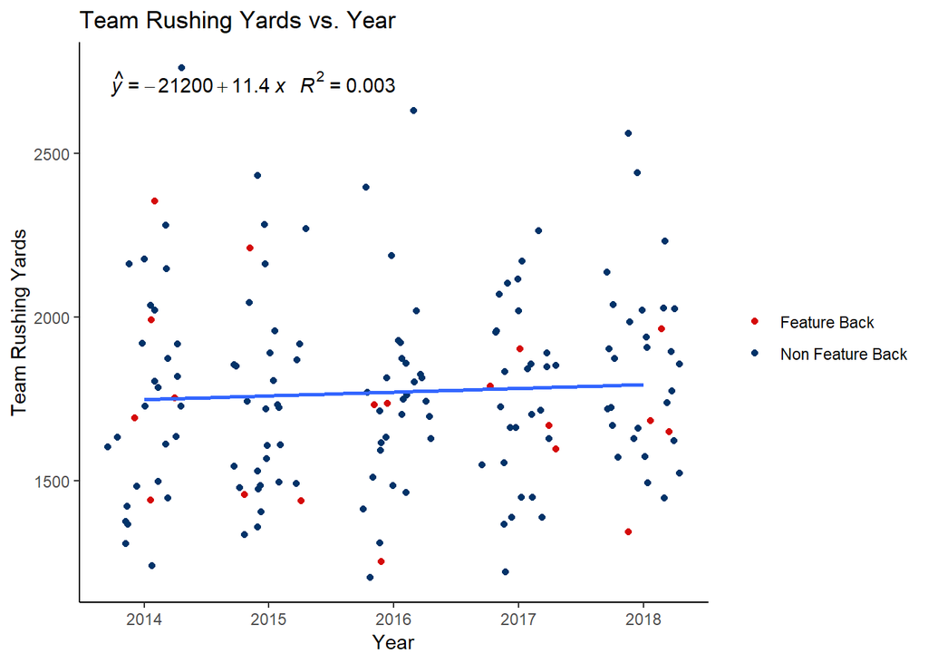

As we can see here there is actually very little change year over year for rushing yards. If anything, rushing yardage is actually slightly increasing , however the relationship of the two is insignificant. This goes against the idea that the modern NFL running game is on the decline. This begs the question however, does an increase in team rushing yards actually lead to increased success? Perhaps there are simply teams that run more than others but that has no impact on the general win percentage of teams.

Lets get a sense of which teams tend to run more. Teams like the Patriots, Steelers, and Seahawks are perennial playoff teams but do these teams tend to rush for more yards than other teams?

To get a sense of which teams to look out for, lets take a look at the teams with the highest average win total. Generally 10 wins will get a team to a playoff spot so which teams have been averaging over 10 wins a year?

Teams like the Patriots and Steelers are always in the playoffs but is this a result of a more effective running game?

| Team | Average Wins |
| --- | --- |
| New England Patriots | 12.4 |
| Kansas City Chiefs | 10.8 |
| Pittsburgh Steelers | 10.8 |
| Los Angeles Chargers | 10.5 |
| Seattle Seahawks | 10.2 |

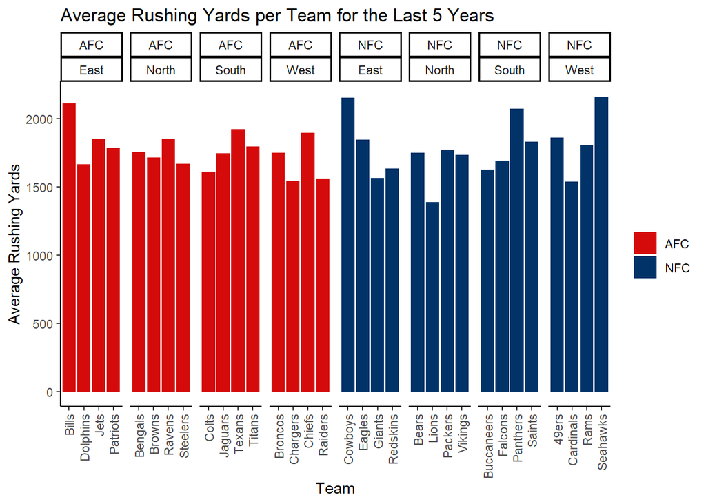

Of the teams averaging over 10 wins per season the past 5 years, only the Seahawks are averaging more than 2000 yards rushing over that same time period. The Patriots, Steelers, and Chiefs all fall in the middle of the pack while the Chargers have been averaging one of the lowest rushing totals in the entire NFL over the past 5 years.

All of this doesn’t look too good on our assumption that more yards from a team’s bell cow back would result in more wins. If we compare a team’s total rushing yards (across all rushing attempts) though we start to see a slightly different story.

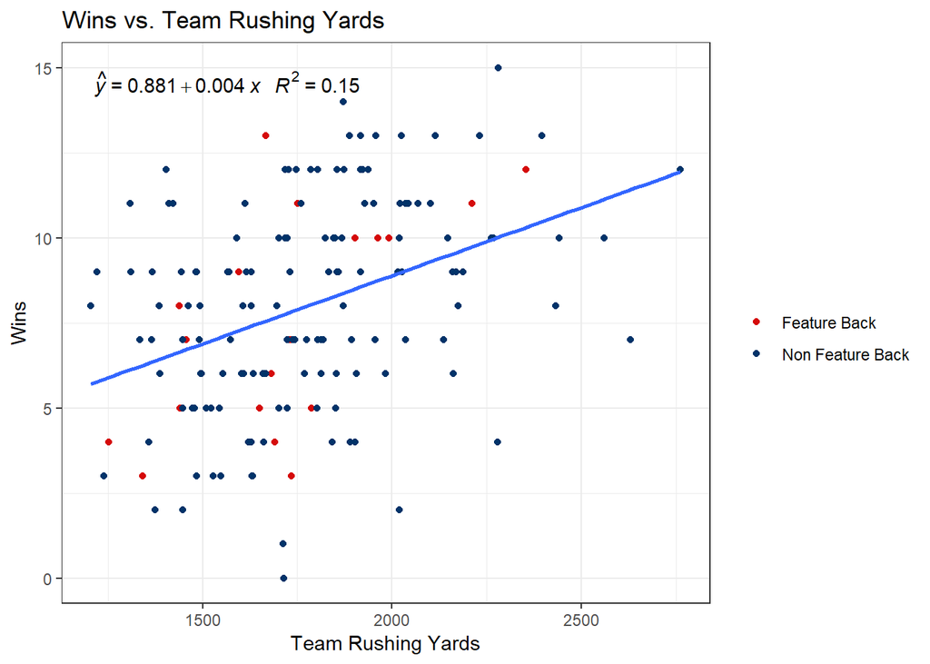

## How Does This Translate to the Individual Player Level?

First lets take a look simply at the number of wins as a function of how many yards the leading rusher gained.

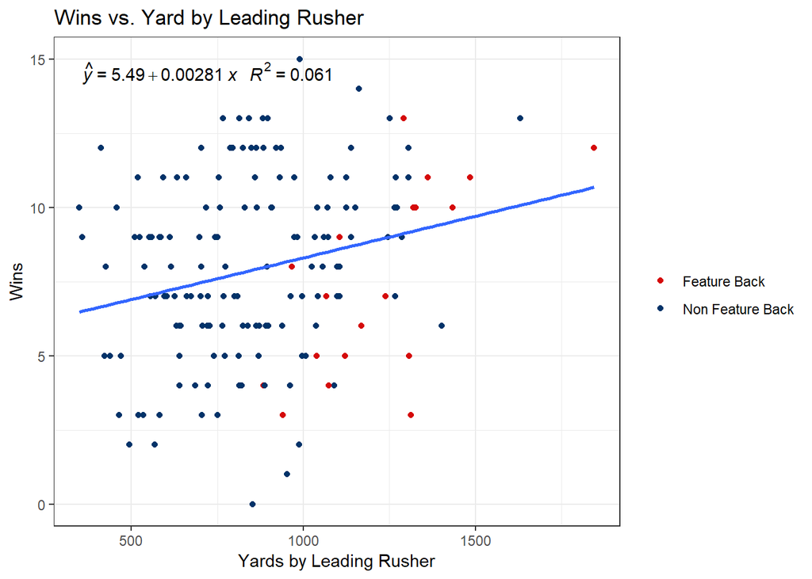

As we expect, we see a positive trend when estimating the expected number of wins by the number of rushing yards by the leading rusher on a team. Here for roughly every 355 yards gained by the leading rusher a given team can expect an additional win. This relationship is significant as well at the p < .05 level as well. So comparing to total team yards, we see a weaker effect but one that is still statistically significant, albeit at a lower confidence level.

We need to be careful however because team rushing yards and leading rusher yards are highly correlated with a Pearson correlation coefficient of 0.568. Since these two fields are highly correlated we expect them to encode much of the same information. What we really care about for this analysis is does giving the featured running back a higher percentage of the workload result in more wins. To do this, we need to look at wins as a function of the percent of total team rushing yards that were gained by the leading rusher. Similarly we want to look at wins as a function of the percent of team rushing attempts taken by the leading rusher.

As evidenced below, when you look at wins as a function of what percentage of yards the leading rusher gained for a team, we see a much weaker trend.

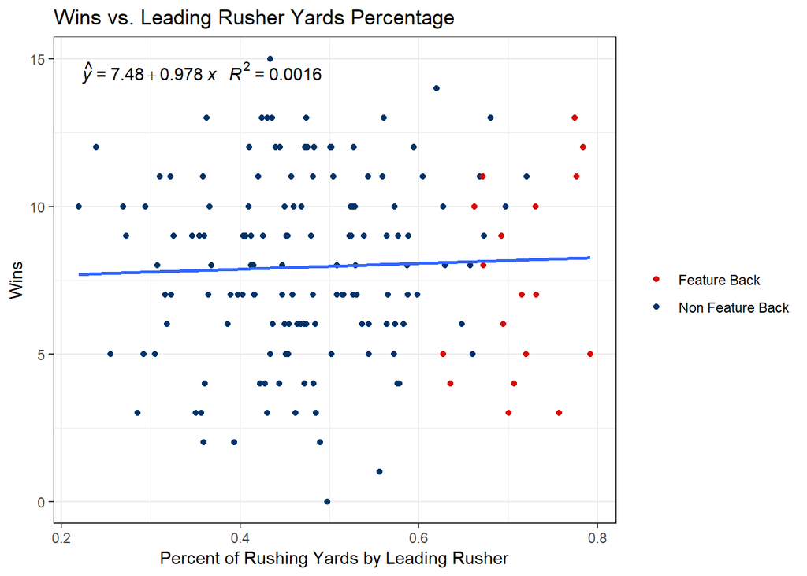

The trend is still positive, but with an extremely weak R<sup>2</sup> = 0.0016. Looking further, we can see that this relationship is in no way significant with a p-value of 0.61. This distribution can be produced by and potentially is a result of randomness. Things look even more bleak when we compare wins to the player attempts percentage.

Recall from before that being a feature back is defined as having 65% of your team’s rushing attempts or greater so here we see a clear segregation of feature and non-feature backs.

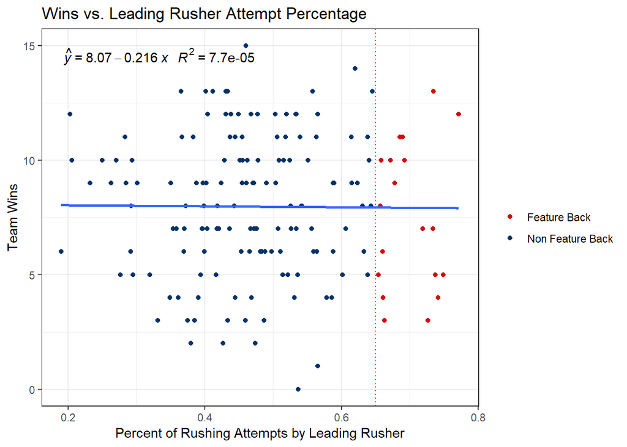

Here we actually even see a slightly negative slope to our line indicating that one player taking a larger portion of a teams snaps may actually be detrimental to a teams success. This trend is very slight however and contains no statistical significance (p-value = 0.9123) so perhaps a more accurate statement would be that there is no trend positive or negative between the percentage of attempts taken by a given player and a the number of wins a team can expect in a given season.

# So what can we say?

| Bell Cow? | Average Wins |
| --- | --- |
| Feature Back | 7.53 |
| Non Feature Back | 8.03 |

Things aren’t looking good for our bell cow running backs. If you start comparing wins across teams with and without a featured running back, things don’t look much better. Teams with a featured running back on average are winning half a game less each year than those without. That’s some bad news bears.

After this analysis, it is safe to say that teams with a well performing running game can expect on average more wins in a season than a team who struggles to run the ball. This makes sense as the more rushing yards a team has, generally the more efficient their offense is and the more points they will score. All those factors make winning games much easier.

What we cannot conclude though, is that all those rushing yards need to go through one person. The percentage of rushing yards and rushing attempts that go through one person seems to have no significant effect on the number of wins a team should expect in a season. So in all what this means is get your rushing yards however you can. Having a running back by committee would seem to be just as effective as having that one three down bell cow back that your offense runs through when it comes to expected added wins. There are other considerations such as:

- Does paying a feature back have a negative effect on the other talent a team can surround him with?
- How does having your leading rusher also be your QB effect the running game and subsequently wins?
- What type of back is most effective? i.e. Hammer vs. scat vs. well-rounded running back

These questions are outside the scope of this analysis but would all be questions well worth asking.

If you’ve enjoyed this analysis, follow me on twitter @MrOhDubbs. Feel free to reach out with questions or with suggestions on what I should do a statistical dive on next!